# R Notebook

Loading the relevant data

```r
save_rds_path <- 'C:/Users/DBT3KD/Desktop/Etude_macro_elec/prix_electricite_gitlab/VAR_analysis/VAR_output/plot_irfs'
setwd(save_rds_path)
readRDS
```

[output not shown]

```r
weak_instruments_pointwise_MBB <- readRDS("weak_instruments_pointwise_MBB.rds")
weak_instruments_bondferroni_MBB <- readRDS("weak_instruments_bondferroni_MBB.rds")
strong_instruments_lambda_MBB <- readRDS( "strong_instruments_lambda_MBB.rds")

weak_instruments_pointwise_log_MBB <- readRDS("weak_instruments_pointwise_log_MBB.rds")
weak_instruments_bondferroni_log_MBB <- readRDS("weak_instruments_bondferroni_log_MBB.rds")
strong_instruments_lambda_log_MBB <- readRDS( "strong_instruments_lambda_log_MBB.rds")


weak_instruments_pointwise_GK <- readRDS("weak_instruments_pointwise_GK.rds")
weak_instruments_bondferroni_GK <- readRDS("weak_instruments_bondferroni_GK.rds")
strong_instruments_lambda_GK <- readRDS("strong_instruments_lambda_GK.rds")

weak_instruments_pointwise_log_GK <- readRDS("weak_instruments_pointwise_log_GK.rds")
weak_instruments_bondferroni_log_GK <- readRDS("weak_instruments_bondferroni_log_GK.rds")
strong_instruments_lambda_log_GK <- readRDS( "strong_instruments_lambda_log_GK.rds")

weak_instruments_pointwise_GK_control <- readRDS("weak_instruments_pointwise_GK_control.rds")
weak_instruments_bondferroni_GK_control <- readRDS("weak_instruments_bondferroni_GK_control.rds")
strong_instruments_lambda_GK_control <- readRDS("strong_instruments_lambda_GK_control.rds")


strong_instruments_lambda_index_MBB <- readRDS("strong_instruments_lambda_index_MBB.rds")
strong_instruments_lambda_index_GK <- readRDS("strong_instruments_lambda_index_GK.rds")
```

# Full parameter Confidence set

Build another custom legend

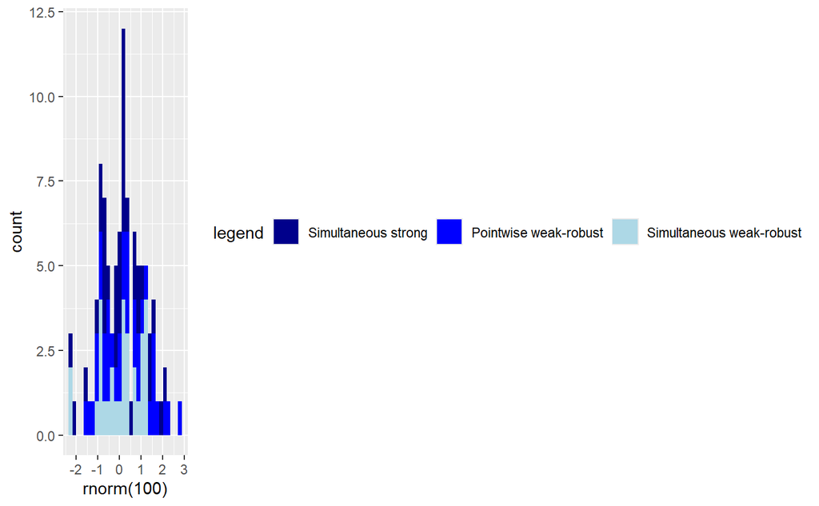

```r
library(ggplot2)
simul_data <- as.data.frame(rnorm(100))
colors <- c( 'Simultaneous strong','Pointwise weak-robust', 'Simultaneous weak-robust')
simul_data$legend <- rep(colors, length.out = 20)
# fake plot just to construct the correct legend
plot_legend <- ggplot(data =simul_data, aes(x=rnorm(100), fill = legend))+
  geom_histogram()+
  theme( legend.direction = "horizontal")+
scale_fill_manual(
    values = c("darkblue", "blue", "lightblue"),
    labels = c( 'Simultaneous strong','Pointwise weak-robust', 'Simultaneous weak-robust'),
    drop=FALSE
  )
# Légende personnalisée (à ajuster selon vos besoins)
custom_legend <- cowplot::get_legend(plot_legend)
plot_legend
```

On veut d’abord comparer à quel point l’un ou l’autre est le plus conservatif entre -le full parameter confidence set qui est le produit echantillonné de deux confidence sets. -le Bonferroni sur chaque pointwise

Pas photo, le Bonferroni etant donne la dimension du vecteur demande un facteur 20 supplementaire de confidence donc tres conservatif

Par contre j’ai peur que blue ne soit pas inclus dans steelblue Inclusion theorique a verifier Peut etre que cela vient d’un mauvais echantillonage des thetas et des A

Maintenant, on trace la figure finale

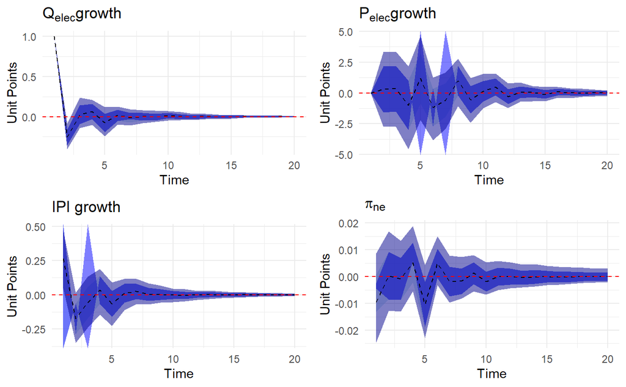

```r
library(latex2exp)

names <- c('$Q_{elec} growth$','$P_{elec} growth$', "IPI growth", '$\\pi_{ne}$')

n <- length(names)
plot_irf_mini_panel_tot <- function(i){
  #i=1
  main_prediction <- lambda_0[, i, 1]
  time_horizon <- 1:20

  strong_band_inf <-
    strong_instruments_lambda_GK[,i,"lower","lambda_01"]
  strong_band_sup <-
    strong_instruments_lambda_GK[,i,"upper","lambda_01"]


  pointwise_inf_weak_band <-
    weak_instruments_pointwise_GK[,i,"lower","lambda_01"]
  pointwise_sup_weak_band <-
    weak_instruments_pointwise_GK[, i,"upper","lambda_01"]

  bonferroni_inf_weak_band <-
    weak_instruments_bondferroni_GK[, i,"lower","lambda_01"]
  bonferroni_sup_weak_band <-
    weak_instruments_bondferroni_GK[, i,"upper","lambda_01"]


  # Plot the responses for each variable

  my_plot <- ggplot()+

  geom_ribbon(aes(x=time_horizon, ymin = bonferroni_inf_weak_band,
        ymax = bonferroni_sup_weak_band), fill = "lightblue", alpha = 0.5) +

    geom_ribbon(aes(x=time_horizon, ymin = pointwise_inf_weak_band,
        ymax = pointwise_sup_weak_band), fill = "blue", alpha = 0.5) +

       geom_ribbon(aes(x=time_horizon, ymin = strong_band_inf,
        ymax = strong_band_sup), fill = "darkblue", alpha = 0.5) +

    # ggtitle(expression(paste(names[i]))) +
    labs(title = TeX(names[i]),
      x = "Time",
      y = "Unit Points") +
    geom_line(aes(x=time_horizon, y= main_prediction), linetype='dashed')+
    geom_hline(yintercept = 0, linetype = 'dashed', color = 'red') +
    scale_x_continuous()+
    scale_y_continuous()+
    # Add confidence bands
    theme_minimal()
  return(my_plot)
}


# Apply the function to the sequence 3:10
results <- lapply(c(1:n) , plot_irf_mini_panel_tot)

# Arrange the plots in a grid
plots_grid <- do.call("grid.arrange", c(results, nrow = 2))
```

[figure not shown]

```r
final_plot <- plot_grid(plots_grid, custom_legend , ncol = 1, rel_heights = c(1, 0.1))

title <- ggdraw() +
  draw_label(TeX('$P_{elec}$ shock IRF'), fontface = 'bold', x = 0.5, hjust = 0.5)

# Combine the title and the final plot with legend
final_plot_with_title <- plot_grid(title, final_plot, ncol = 1, rel_heights = c(0.1, 1))

# Display the final plot
print(final_plot_with_title)
```

Meme figure pour un choc de demande

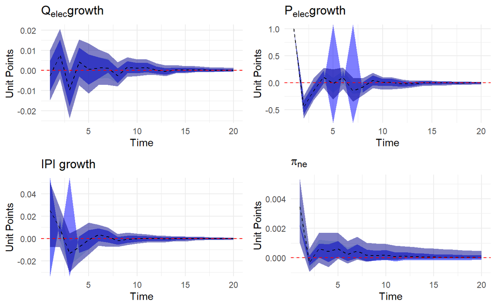

```r
plot_irf_mini_panel_tot <- function(i){
  # i=1

  main_prediction <- lambda_0[, i, 2]
  time_horizon <- 1:20

  strong_band_inf <-
    strong_instruments_lambda_GK[,i,"lower","lambda_02"]
  strong_band_sup <-
    strong_instruments_lambda_GK[,i,"upper","lambda_02"]


  pointwise_inf_weak_band <-
    weak_instruments_pointwise_GK[,i,"lower","lambda_02"]
  pointwise_sup_weak_band <-
    weak_instruments_pointwise_GK[, i,"upper","lambda_02"]

  bonferroni_inf_weak_band <-
    weak_instruments_bondferroni_GK[, i,"lower","lambda_02"]
  bonferroni_sup_weak_band <-
    weak_instruments_bondferroni_GK[, i,"upper","lambda_02"]
  # Plot the responses for each variable

  my_plot <- ggplot()+

  geom_ribbon(aes(x=time_horizon, ymin = bonferroni_inf_weak_band,
        ymax = bonferroni_sup_weak_band), fill = "lightblue", alpha = 0.5) +

    geom_ribbon(aes(x=time_horizon, ymin = pointwise_inf_weak_band,
        ymax = pointwise_sup_weak_band), fill = "blue", alpha = 0.5) +

       geom_ribbon(aes(x=time_horizon, ymin = strong_band_inf,
        ymax = strong_band_sup), fill = "darkblue", alpha = 0.5) +

    # ggtitle(expression(paste(names[i]))) +
    labs(title = TeX(names[i]),
      x = "Time",
      y = "Unit Points") +
    geom_line(aes(x=time_horizon, y= main_prediction), linetype='dashed')+
    geom_hline(yintercept = 0, linetype = 'dashed', color = 'red') +
    # Add confidence bands
    theme_minimal()
  return(my_plot)
}


# Apply the function to the sequence 3:10
results <- lapply(c(1:n) , plot_irf_mini_panel_tot)

# Arrange the plots in a grid
plots_grid <- do.call("grid.arrange", c(results, nrow = 2))
```

[figure not shown]

```r
final_plot <- plot_grid(plots_grid, custom_legend , ncol = 1, rel_heights = c(1, 0.1))

title <- ggdraw() +
  draw_label(TeX('$Q_{elec}$ shock IRF'), fontface = 'bold', x = 0.5, hjust = 0.5)
# Combine the title and the final plot with legend
final_plot_with_title <- plot_grid(title, final_plot, ncol = 1, rel_heights = c(0.1, 1))

# Display the final plot
print(final_plot_with_title)
```

# Using the MBB design

For a quantity shock,

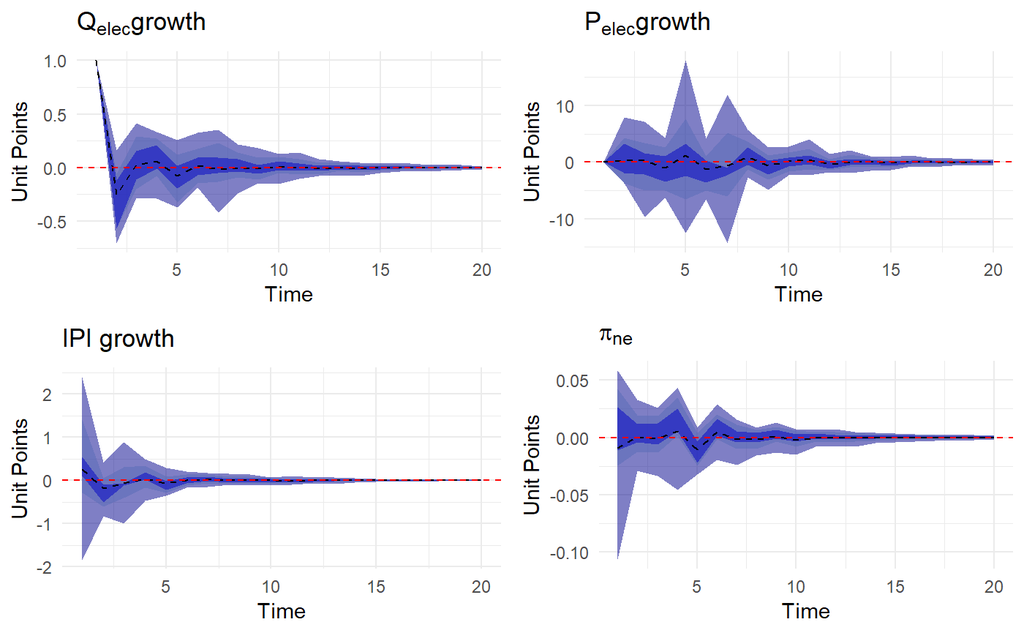

```r
library(latex2exp)

names <- c('$Q_{elec} growth$','$P_{elec} growth$', "IPI growth", '$\\pi_{ne}$')

plot_irf_mini_panel_tot <- function(i){
  #i=1
  main_prediction <- lambda_0[, i, 1]
  time_horizon <- 1:20

  strong_band_inf <-
    strong_instruments_lambda_MBB[,i,"lower","lambda_01"]
  strong_band_sup <-
    strong_instruments_lambda_MBB[,i,"upper","lambda_01"]


  pointwise_inf_weak_band <-
    weak_instruments_pointwise_MBB[,i,"lower","lambda_01"]
  pointwise_sup_weak_band <-
    weak_instruments_pointwise_MBB[, i,"upper","lambda_01"]

  bonferroni_inf_weak_band <-
    weak_instruments_bondferroni_MBB[, i,"lower","lambda_01"]
  bonferroni_sup_weak_band <-
    weak_instruments_bondferroni_MBB[, i,"upper","lambda_01"]


  # Plot the responses for each variable

  my_plot <- ggplot()+

  geom_ribbon(aes(x=time_horizon, ymin = bonferroni_inf_weak_band,
        ymax = bonferroni_sup_weak_band), fill = "lightblue", alpha = 0.5) +

    geom_ribbon(aes(x=time_horizon, ymin = pointwise_inf_weak_band,
        ymax = pointwise_sup_weak_band), fill = "blue", alpha = 0.5) +

       geom_ribbon(aes(x=time_horizon, ymin = strong_band_inf,
        ymax = strong_band_sup), fill = "darkblue", alpha = 0.5) +

    # ggtitle(expression(paste(names[i]))) +
    labs(title = TeX(names[i]),
      x = "Time",
      y = "Unit Points") +
    geom_line(aes(x=time_horizon, y= main_prediction), linetype='dashed')+
    geom_hline(yintercept = 0, linetype = 'dashed', color = 'red') +
    scale_x_continuous()+
    scale_y_continuous()+
    # Add confidence bands
    theme_minimal()
  return(my_plot)
}


# Apply the function to the sequence 3:10
results <- lapply(c(1:n) , plot_irf_mini_panel_tot)

# Arrange the plots in a grid
plots_grid <- do.call("grid.arrange", c(results, nrow = 2))
```

[figure not shown]

```r
final_plot <- plot_grid(plots_grid, custom_legend , ncol = 1, rel_heights = c(1, 0.1))

title <- ggdraw() +
  draw_label(TeX('$P_{elec}$ shock IRF'), fontface = 'bold', x = 0.5, hjust = 0.5)

# Combine the title and the final plot with legend
final_plot_with_title <- plot_grid(title, final_plot, ncol = 1, rel_heights = c(0.1, 1))

# Display the final plot
print(final_plot_with_title)
```

For a price shock,

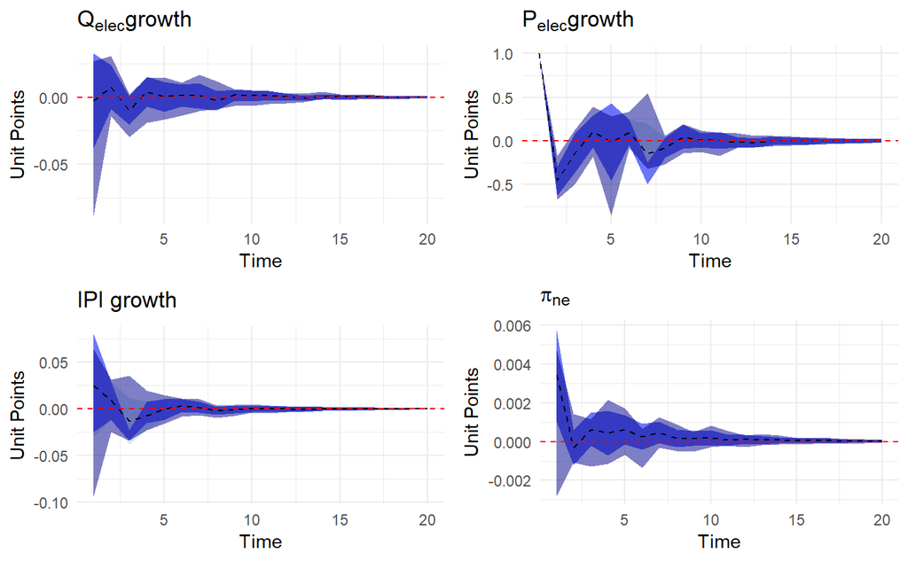

```r
plot_irf_mini_panel_tot <- function(i){
  # i=1

  main_prediction <- lambda_0[, i, 2]
  time_horizon <- 1:20

  strong_band_inf <-
    strong_instruments_lambda_MBB[,i,"lower","lambda_02"]
  strong_band_sup <-
    strong_instruments_lambda_MBB[,i,"upper","lambda_02"]


  pointwise_inf_weak_band <-
    weak_instruments_pointwise_MBB[,i,"lower","lambda_02"]
  pointwise_sup_weak_band <-
    weak_instruments_pointwise_MBB[, i,"upper","lambda_02"]

  bonferroni_inf_weak_band <-
    weak_instruments_bondferroni_MBB[, i,"lower","lambda_02"]
  bonferroni_sup_weak_band <-
    weak_instruments_bondferroni_MBB[, i,"upper","lambda_02"]
  # Plot the responses for each variable

  my_plot <- ggplot()+

  geom_ribbon(aes(x=time_horizon, ymin = bonferroni_inf_weak_band,
        ymax = bonferroni_sup_weak_band), fill = "lightblue", alpha = 0.5) +

    geom_ribbon(aes(x=time_horizon, ymin = pointwise_inf_weak_band,
        ymax = pointwise_sup_weak_band), fill = "blue", alpha = 0.5) +

       geom_ribbon(aes(x=time_horizon, ymin = strong_band_inf,
        ymax = strong_band_sup), fill = "darkblue", alpha = 0.5) +

    # ggtitle(expression(paste(names[i]))) +
    labs(title = TeX(names[i]),
      x = "Time",
      y = "Unit Points") +
    geom_line(aes(x=time_horizon, y= main_prediction), linetype='dashed')+
    geom_hline(yintercept = 0, linetype = 'dashed', color = 'red') +
    # Add confidence bands
    theme_minimal()
  return(my_plot)
}


# Apply the function to the sequence 3:10
results <- lapply(c(1:n) , plot_irf_mini_panel_tot)

# Arrange the plots in a grid
plots_grid <- do.call("grid.arrange", c(results, nrow = 2))
```

[figure not shown]

```r
final_plot <- plot_grid(plots_grid, custom_legend , ncol = 1, rel_heights = c(1, 0.1))

title <- ggdraw() +
  draw_label(TeX('$Q_{elec}$ shock IRF'), fontface = 'bold', x = 0.5, hjust = 0.5)
# Combine the title and the final plot with legend
final_plot_with_title <- plot_grid(title, final_plot, ncol = 1, rel_heights = c(0.1, 1))

# Display the final plot
print(final_plot_with_title)
```

#Response in levels

On convertit la réponse pour présenter des IRFs en niveau

```r
lambda_levels <- 0.01*lambda_0 +1
lambda_levels <- apply(lambda_levels , 2, cumprod)


simul_data <- as.data.frame(rnorm(100))
colors <- c( 'MBB','GK')
simul_data$legend <- rep(colors, length.out = 20)
# fake plot just to construct the correct legend
plot_legend_index <- ggplot(data =simul_data, aes(x=rnorm(100), fill = legend))+
  geom_histogram()+
  theme( legend.direction = "horizontal")+
scale_fill_manual(
    values = c("red", "yellow"),
    labels = c( 'MBB','GK'),
    drop=FALSE
  )
# Légende personnalisée (à ajuster selon vos besoins)
custom_legend_index  <- cowplot::get_legend(plot_legend_index)
```

For now, I just have strong instrument version. not sure their is a tcl on their cumulative product

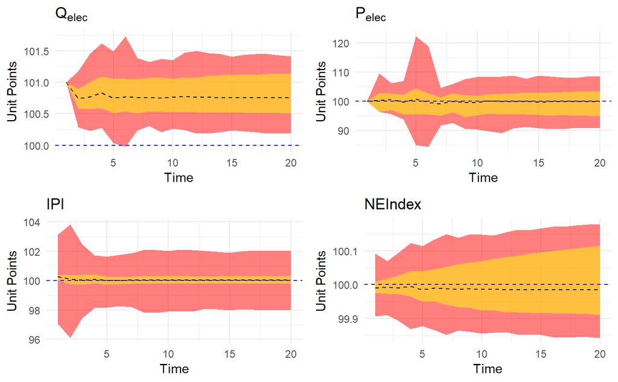

```r
names <- c('$Q_{elec}$','$P_{elec}$', "IPI", '$NE Index$')

lambda_levels <- apply(0.01 * lambda_0[,,1] + 1, 2, cumprod)
plot_irf_mini_panel_strong <- function(i){
  #i=1
  main_prediction <- lambda_levels [,i]  # Compute cumulative product
  time_horizon <- 1:20

  strong_band_inf_MBB <-
    strong_instruments_lambda_index_MBB[,i,"lower","lambda_01"]
  strong_band_sup_MBB <-
    strong_instruments_lambda_index_MBB[,i,"upper","lambda_01"]

  strong_band_inf_GK <-
    strong_instruments_lambda_index_GK[,i,"lower","lambda_01"]
  strong_band_sup_GK <-
    strong_instruments_lambda_index_GK[,i,"upper","lambda_01"]

  # Plot the responses for each variable

  my_plot <- ggplot()+
       geom_ribbon(aes(x=time_horizon, ymin = 100*strong_band_inf_MBB,
        ymax = 100*strong_band_sup_MBB), fill = "red", alpha = 0.5) +
      geom_ribbon(aes(x=time_horizon, ymin = 100*strong_band_inf_GK,
        ymax = 100*strong_band_sup_GK), fill = "yellow", alpha = 0.5) +

    # ggtitle(expression(paste(names[i]))) +
    labs(title = TeX(names[i]),
      x = "Time",
      y = "Unit Points") +
    geom_line(aes(x=time_horizon, y=100* main_prediction), linetype='dashed')+
    geom_hline(yintercept = 100, linetype = 'dashed', color = 'blue') +
    # Add confidence bands
    theme_minimal()
  return(my_plot)
}


# Apply the function to the sequence 3:10
results <- lapply(c(1:n) , plot_irf_mini_panel_strong)

# Arrange the plots in a grid
plots_grid <- do.call("grid.arrange", c(results, nrow = 2))
```

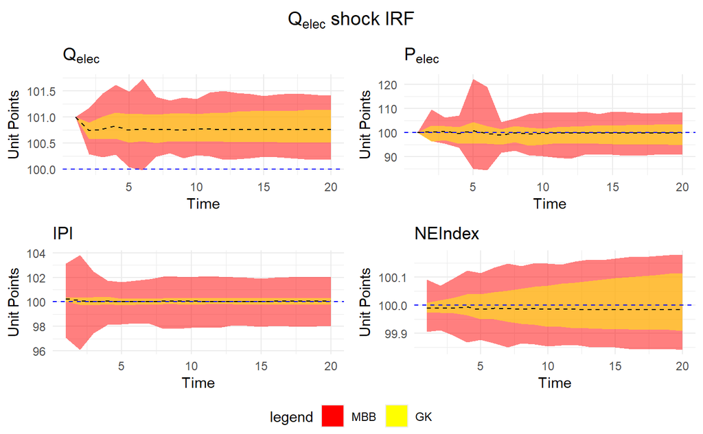

```r
final_plot <- plot_grid(plots_grid, custom_legend_index , ncol = 1, rel_heights = c(1, 0.1))

title <- ggdraw() +
  draw_label(TeX('$Q_{elec}$ shock IRF'), fontface = 'bold', x = 0.5, hjust = 0.5)
# Combine the title and the final plot with legend
final_plot_with_title <- plot_grid(title, final_plot, ncol = 1, rel_heights = c(0.1, 1))

# Display the final plot
print(final_plot_with_title)
```

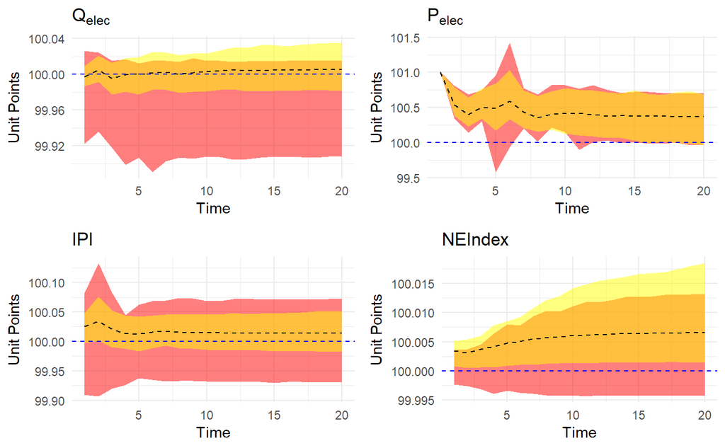

```r
names <- c('$Q_{elec}$','$P_{elec}$', "IPI", '$NE Index$')

lambda_levels <- apply(0.01 * lambda_0[,,2] + 1, 2, cumprod)
plot_irf_mini_panel_strong <- function(i){
  #i=1
  main_prediction <- lambda_levels [,i]  # Compute cumulative product
  time_horizon <- 1:20

  strong_band_inf_MBB <-
    strong_instruments_lambda_index_MBB[,i,"lower","lambda_02"]
  strong_band_sup_MBB <-
    strong_instruments_lambda_index_MBB[,i,"upper","lambda_02"]

  strong_band_inf_GK <-
    strong_instruments_lambda_index_GK[,i,"lower","lambda_02"]
  strong_band_sup_GK <-
    strong_instruments_lambda_index_GK[,i,"upper","lambda_02"]

  # Plot the responses for each variable

  my_plot <- ggplot()+
       geom_ribbon(aes(x=time_horizon, ymin = 100*strong_band_inf_MBB,
        ymax = 100*strong_band_sup_MBB), fill = "red", alpha = 0.5) +
      geom_ribbon(aes(x=time_horizon, ymin = 100*strong_band_inf_GK,
        ymax = 100*strong_band_sup_GK), fill = "yellow", alpha = 0.5) +

    # ggtitle(expression(paste(names[i]))) +
    labs(title = TeX(names[i]),
      x = "Time",
      y = "Unit Points") +
    geom_line(aes(x=time_horizon, y=100* main_prediction), linetype='dashed')+
    geom_hline(yintercept = 100, linetype = 'dashed', color = 'blue') +
    # Add confidence bands
    theme_minimal()
  return(my_plot)
}


# Apply the function to the sequence 3:10
results <- lapply(c(1:n) , plot_irf_mini_panel_strong)

# Arrange the plots in a grid
plots_grid <- do.call("grid.arrange", c(results, nrow = 2))
```

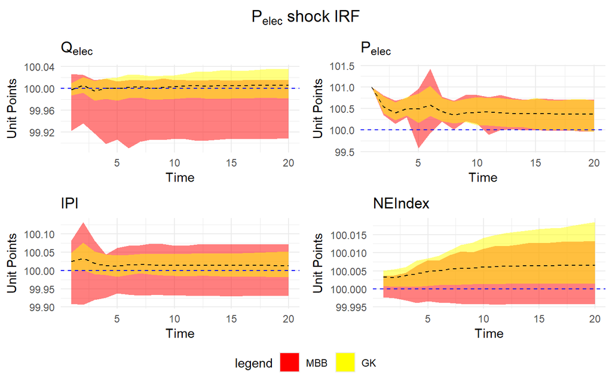

```r
final_plot <- plot_grid(plots_grid, custom_legend_index , ncol = 1, rel_heights = c(1, 0.1))

title <- ggdraw() +
  draw_label(TeX('$P_{elec}$ shock IRF'), fontface = 'bold', x = 0.5, hjust = 0.5)
# Combine the title and the final plot with legend
final_plot_with_title <- plot_grid(title, final_plot, ncol = 1, rel_heights = c(0.1, 1))

# Display the final plot
print(final_plot_with_title)
```

# VAR in log-levels

First using MBB for a quantity shock

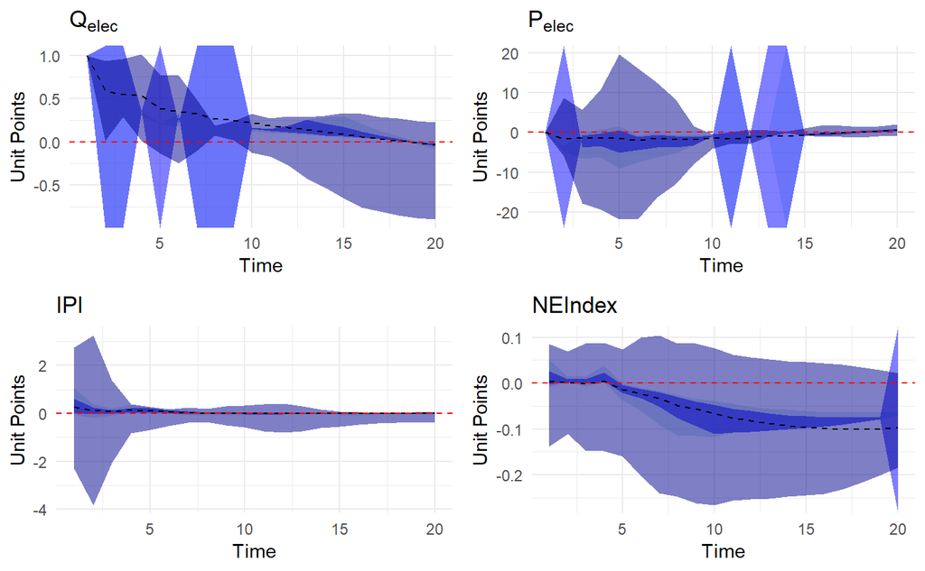

```r
library(latex2exp)

names <- c('$Q_{elec}$','$P_{elec}$', "IPI", '$NE Index$')

n <- length(names)
plot_irf_mini_panel_tot <- function(i){
  #i=1
  main_prediction <- lambda_0_log[, i, 1]
  time_horizon <- 1:20

  strong_band_inf <-
    strong_instruments_lambda_log_MBB[,i,"lower","lambda_01"]
  strong_band_sup <-
    strong_instruments_lambda_log_MBB[,i,"upper","lambda_01"]


  pointwise_inf_weak_band <-
    weak_instruments_pointwise_log_MBB[,i,"lower","lambda_01"]
  pointwise_sup_weak_band <-
    weak_instruments_pointwise_log_MBB[, i,"upper","lambda_01"]

  bonferroni_inf_weak_band <-
    weak_instruments_bondferroni_log_MBB[, i,"lower","lambda_01"]
  bonferroni_sup_weak_band <-
    weak_instruments_bondferroni_log_MBB[, i,"upper","lambda_01"]



  # Plot the responses for each variable

  my_plot <- ggplot()+

  geom_ribbon(aes(x=time_horizon, ymin = bonferroni_inf_weak_band,
        ymax = bonferroni_sup_weak_band), fill = "lightblue", alpha = 0.5) +

    geom_ribbon(aes(x=time_horizon, ymin = pointwise_inf_weak_band,
        ymax = pointwise_sup_weak_band), fill = "blue", alpha = 0.5) +

       geom_ribbon(aes(x=time_horizon, ymin = strong_band_inf,
        ymax = strong_band_sup), fill = "darkblue", alpha = 0.5) +

    # ggtitle(expression(paste(names[i]))) +
    labs(title = TeX(names[i]),
      x = "Time",
      y = "Unit Points") +
    geom_line(aes(x=time_horizon, y= main_prediction), linetype='dashed')+
    geom_hline(yintercept = 0, linetype = 'dashed', color = 'red') +
    scale_x_continuous()+
    scale_y_continuous()+
    # Add confidence bands
    theme_minimal()
  return(my_plot)
}


# Apply the function to the sequence 3:10
results <- lapply(c(1:n) , plot_irf_mini_panel_tot)

# Arrange the plots in a grid
plots_grid <- do.call("grid.arrange", c(results, nrow = 2))
```

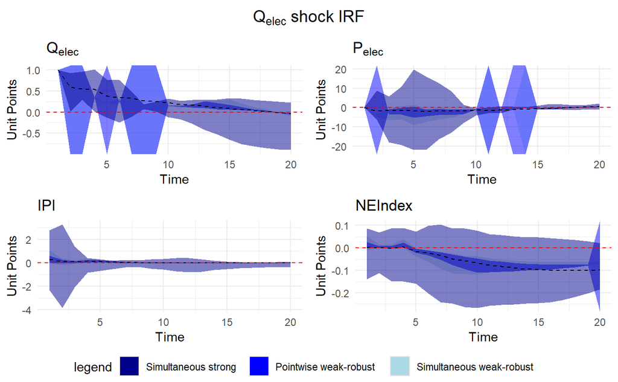

```r
final_plot <- plot_grid(plots_grid, custom_legend , ncol = 1, rel_heights = c(1, 0.1))

title <- ggdraw() +
  draw_label(TeX('$Q_{elec}$ shock IRF'), fontface = 'bold', x = 0.5, hjust = 0.5)

# Combine the title and the final plot with legend
final_plot_with_title <- plot_grid(title, final_plot, ncol = 1, rel_heights = c(0.1, 1))

# Display the final plot
print(final_plot_with_title)
```

Then using MBB for a price shock

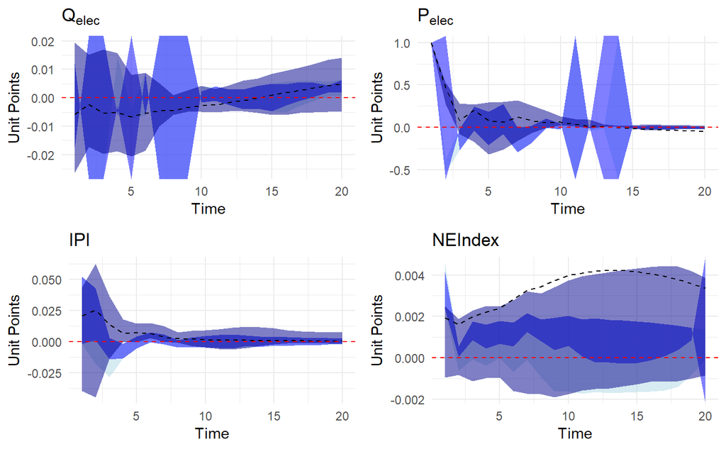

```r
library(latex2exp)

names <- c('$Q_{elec}$','$P_{elec}$', "IPI", '$NE Index$')

n <- length(names)
plot_irf_mini_panel_tot <- function(i){
  #i=1
  main_prediction <- lambda_0_log[, i, 2]
  time_horizon <- 1:20

  strong_band_inf <-
    strong_instruments_lambda_log_MBB[,i,"lower","lambda_02"]
  strong_band_sup <-
    strong_instruments_lambda_log_MBB[,i,"upper","lambda_02"]


  pointwise_inf_weak_band <-
    weak_instruments_pointwise_log_MBB[,i,"lower","lambda_02"]
  pointwise_sup_weak_band <-
    weak_instruments_pointwise_log_MBB[, i,"upper","lambda_02"]

  bonferroni_inf_weak_band <-
    weak_instruments_bondferroni_log_MBB[, i,"lower","lambda_02"]
  bonferroni_sup_weak_band <-
    weak_instruments_bondferroni_log_MBB[, i,"upper","lambda_02"]



  # Plot the responses for each variable

  my_plot <- ggplot()+

  geom_ribbon(aes(x=time_horizon, ymin = bonferroni_inf_weak_band,
        ymax = bonferroni_sup_weak_band), fill = "lightblue", alpha = 0.5) +

    geom_ribbon(aes(x=time_horizon, ymin = pointwise_inf_weak_band,
        ymax = pointwise_sup_weak_band), fill = "blue", alpha = 0.5) +

       geom_ribbon(aes(x=time_horizon, ymin = strong_band_inf,
        ymax = strong_band_sup), fill = "darkblue", alpha = 0.5) +

    # ggtitle(expression(paste(names[i]))) +
    labs(title = TeX(names[i]),
      x = "Time",
      y = "Unit Points") +
    geom_line(aes(x=time_horizon, y= main_prediction), linetype='dashed')+
    geom_hline(yintercept = 0, linetype = 'dashed', color = 'red') +
    scale_x_continuous()+
    scale_y_continuous()+
    # Add confidence bands
    theme_minimal()
  return(my_plot)
}


# Apply the function to the sequence 3:10
results <- lapply(c(1:n) , plot_irf_mini_panel_tot)

# Arrange the plots in a grid
plots_grid <- do.call("grid.arrange", c(results, nrow = 2))
```

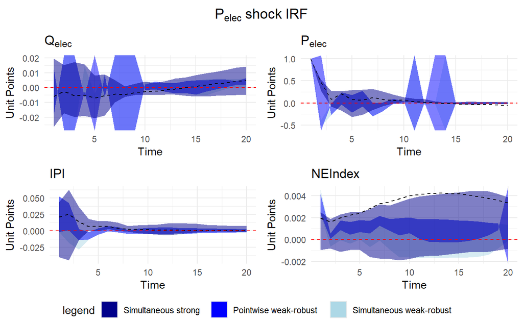

```r
final_plot <- plot_grid(plots_grid, custom_legend , ncol = 1, rel_heights = c(1, 0.1))

title <- ggdraw() +
  draw_label(TeX('$P_{elec}$ shock IRF'), fontface = 'bold', x = 0.5, hjust = 0.5)

# Combine the title and the final plot with legend
final_plot_with_title <- plot_grid(title, final_plot, ncol = 1, rel_heights = c(0.1, 1))

# Display the final plot
print(final_plot_with_title)
```

The same for the GK bootstrap scheme

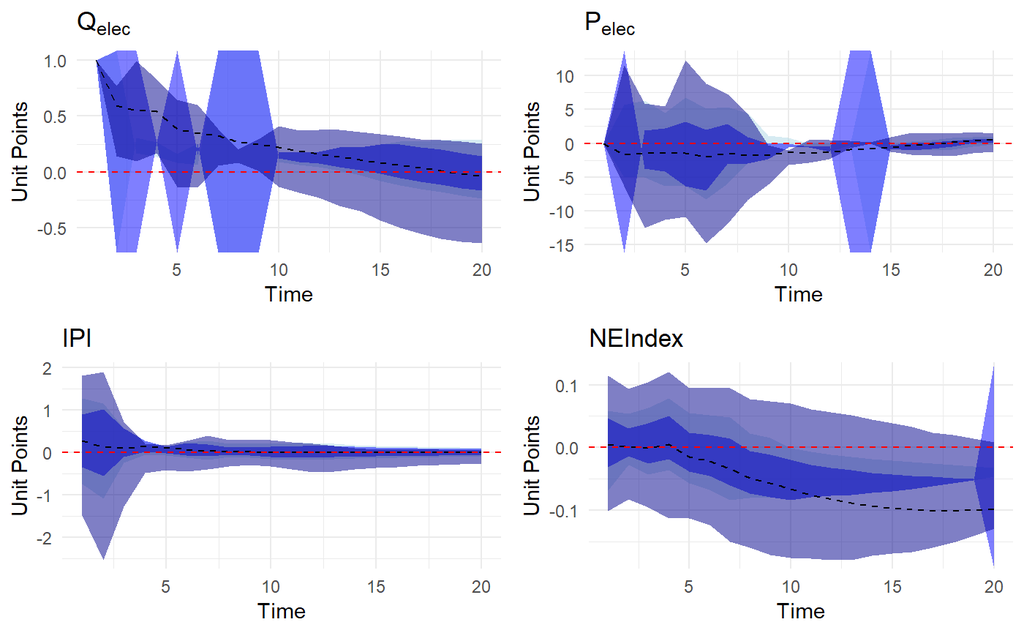

```r
library(latex2exp)

names <- c('$Q_{elec}$','$P_{elec}$', "IPI", '$NE Index$')

n <- length(names)
plot_irf_mini_panel_tot <- function(i){
  #i=1
  main_prediction <- lambda_0_log[, i, 1]
  time_horizon <- 1:20

  strong_band_inf <-
    strong_instruments_lambda_log_GK[,i,"lower","lambda_01"]
  strong_band_sup <-
    strong_instruments_lambda_log_GK[,i,"upper","lambda_01"]


  pointwise_inf_weak_band <-
    weak_instruments_pointwise_log_GK[,i,"lower","lambda_01"]
  pointwise_sup_weak_band <-
    weak_instruments_pointwise_log_GK[, i,"upper","lambda_01"]

  bonferroni_inf_weak_band <-
    weak_instruments_bondferroni_log_GK[, i,"lower","lambda_01"]
  bonferroni_sup_weak_band <-
    weak_instruments_bondferroni_log_GK[, i,"upper","lambda_01"]



  # Plot the responses for each variable

  my_plot <- ggplot()+

  geom_ribbon(aes(x=time_horizon, ymin = bonferroni_inf_weak_band,
        ymax = bonferroni_sup_weak_band), fill = "lightblue", alpha = 0.5) +

    geom_ribbon(aes(x=time_horizon, ymin = pointwise_inf_weak_band,
        ymax = pointwise_sup_weak_band), fill = "blue", alpha = 0.5) +

       geom_ribbon(aes(x=time_horizon, ymin = strong_band_inf,
        ymax = strong_band_sup), fill = "darkblue", alpha = 0.5) +

    # ggtitle(expression(paste(names[i]))) +
    labs(title = TeX(names[i]),
      x = "Time",
      y = "Unit Points") +
    geom_line(aes(x=time_horizon, y= main_prediction), linetype='dashed')+
    geom_hline(yintercept = 0, linetype = 'dashed', color = 'red') +
    scale_x_continuous()+
    scale_y_continuous()+
    # Add confidence bands
    theme_minimal()
  return(my_plot)
}


# Apply the function to the sequence 3:10
results <- lapply(c(1:n) , plot_irf_mini_panel_tot)

# Arrange the plots in a grid
plots_grid <- do.call("grid.arrange", c(results, nrow = 2))
```

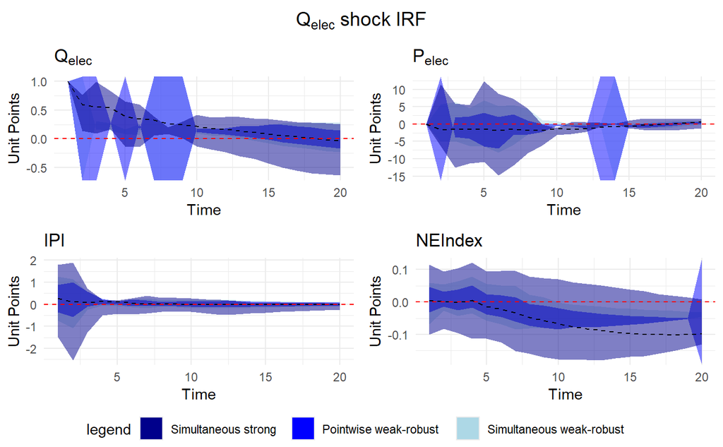

```r
final_plot <- plot_grid(plots_grid, custom_legend , ncol = 1, rel_heights = c(1, 0.1))

title <- ggdraw() +
  draw_label(TeX('$Q_{elec}$ shock IRF'), fontface = 'bold', x = 0.5, hjust = 0.5)

# Combine the title and the final plot with legend
final_plot_with_title <- plot_grid(title, final_plot, ncol = 1, rel_heights = c(0.1, 1))

# Display the final plot
print(final_plot_with_title)
```

The same for price elec shock with GK

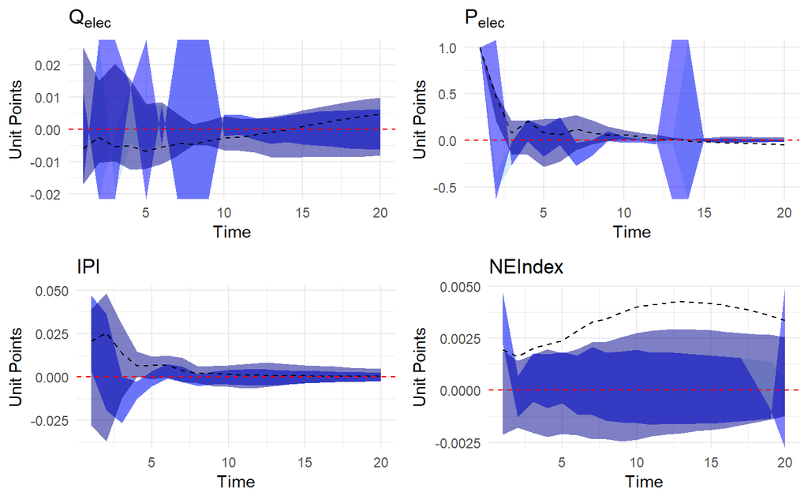

```r
library(latex2exp)

names <- c('$Q_{elec}$','$P_{elec}$', "IPI", '$NE Index$')

n <- length(names)
plot_irf_mini_panel_tot <- function(i){
  #i=1
  main_prediction <- lambda_0_log[, i, 2]
  time_horizon <- 1:20

  strong_band_inf <-
    strong_instruments_lambda_log_GK[,i,"lower","lambda_02"]
  strong_band_sup <-
    strong_instruments_lambda_log_GK[,i,"upper","lambda_02"]


  pointwise_inf_weak_band <-
    weak_instruments_pointwise_log_GK[,i,"lower","lambda_02"]
  pointwise_sup_weak_band <-
    weak_instruments_pointwise_log_GK[, i,"upper","lambda_02"]

  bonferroni_inf_weak_band <-
    weak_instruments_bondferroni_log_GK[, i,"lower","lambda_02"]
  bonferroni_sup_weak_band <-
    weak_instruments_bondferroni_log_GK[, i,"upper","lambda_02"]



  # Plot the responses for each variable

  my_plot <- ggplot()+

  geom_ribbon(aes(x=time_horizon, ymin = bonferroni_inf_weak_band,
        ymax = bonferroni_sup_weak_band), fill = "lightblue", alpha = 0.5) +

    geom_ribbon(aes(x=time_horizon, ymin = pointwise_inf_weak_band,
        ymax = pointwise_sup_weak_band), fill = "blue", alpha = 0.5) +

       geom_ribbon(aes(x=time_horizon, ymin = strong_band_inf,
        ymax = strong_band_sup), fill = "darkblue", alpha = 0.5) +

    # ggtitle(expression(paste(names[i]))) +
    labs(title = TeX(names[i]),
      x = "Time",
      y = "Unit Points") +
    geom_line(aes(x=time_horizon, y= main_prediction), linetype='dashed')+
    geom_hline(yintercept = 0, linetype = 'dashed', color = 'red') +
    scale_x_continuous()+
    scale_y_continuous()+
    # Add confidence bands
    theme_minimal()
  return(my_plot)
}


# Apply the function to the sequence 3:10
results <- lapply(c(1:n) , plot_irf_mini_panel_tot)

# Arrange the plots in a grid
plots_grid <- do.call("grid.arrange", c(results, nrow = 2))
```

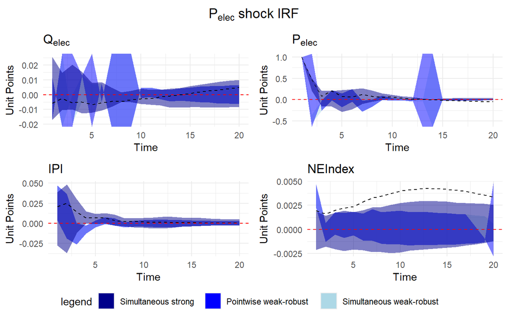

```r
final_plot <- plot_grid(plots_grid, custom_legend , ncol = 1, rel_heights = c(1, 0.1))

title <- ggdraw() +
  draw_label(TeX('$P_{elec}$ shock IRF'), fontface = 'bold', x = 0.5, hjust = 0.5)

# Combine the title and the final plot with legend
final_plot_with_title <- plot_grid(title, final_plot, ncol = 1, rel_heights = c(0.1, 1))

# Display the final plot
print(final_plot_with_title)
```

# Control for gas price

I use a final specification where I do not include gas news shock as an instrument. Instead, I consider only my natural instruments, but I control for gas price in the VAR that we know is a key determinant of electricity price on the period.

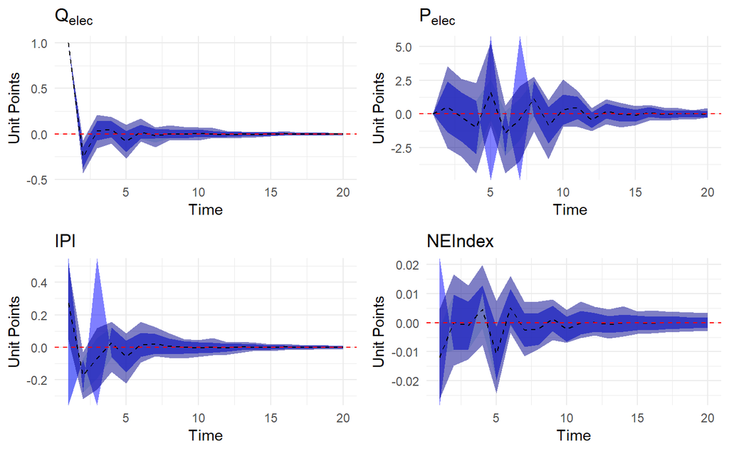

```r
library(latex2exp)

names <- c('$Q_{elec}$','$P_{elec}$', "IPI", '$NE Index$')

n <- length(names)
plot_irf_mini_panel_tot <- function(i){
  #i=1
  main_prediction <- lambda_0_control[, i, 1]
  time_horizon <- 1:20

  strong_band_inf <-
    strong_instruments_lambda_GK_control[,i,"lower","lambda_01"]
  strong_band_sup <-
    strong_instruments_lambda_GK_control[,i,"upper","lambda_01"]


  pointwise_inf_weak_band <-
    weak_instruments_pointwise_GK_control[,i,"lower","lambda_01"]
  pointwise_sup_weak_band <-
    weak_instruments_pointwise_GK_control[, i,"upper","lambda_01"]

  bonferroni_inf_weak_band <-
    weak_instruments_bondferroni_GK_control[, i,"lower","lambda_01"]
  bonferroni_sup_weak_band <-
    weak_instruments_bondferroni_GK_control[, i,"upper","lambda_01"]



  # Plot the responses for each variable

  my_plot <- ggplot()+

  geom_ribbon(aes(x=time_horizon, ymin = bonferroni_inf_weak_band,
        ymax = bonferroni_sup_weak_band), fill = "lightblue", alpha = 0.5) +

    geom_ribbon(aes(x=time_horizon, ymin = pointwise_inf_weak_band,
        ymax = pointwise_sup_weak_band), fill = "blue", alpha = 0.5) +

       geom_ribbon(aes(x=time_horizon, ymin = strong_band_inf,
        ymax = strong_band_sup), fill = "darkblue", alpha = 0.5) +

    # ggtitle(expression(paste(names[i]))) +
    labs(title = TeX(names[i]),
      x = "Time",
      y = "Unit Points") +
    geom_line(aes(x=time_horizon, y= main_prediction), linetype='dashed')+
    geom_hline(yintercept = 0, linetype = 'dashed', color = 'red') +
    scale_x_continuous()+
    scale_y_continuous()+
    # Add confidence bands
    theme_minimal()
  return(my_plot)
}


# Apply the function to the sequence 3:10
results <- lapply(c(1:n) , plot_irf_mini_panel_tot)

# Arrange the plots in a grid
plots_grid <- do.call("grid.arrange", c(results, nrow = 2))
```

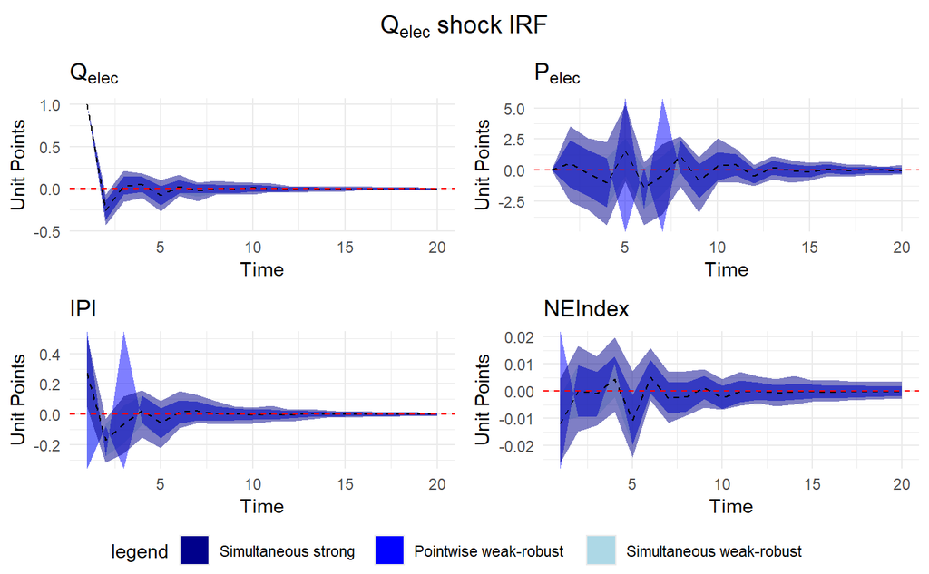

```r
final_plot <- plot_grid(plots_grid, custom_legend , ncol = 1, rel_heights = c(1, 0.1))

title <- ggdraw() +
  draw_label(TeX('$Q_{elec}$ shock IRF'), fontface = 'bold', x = 0.5, hjust = 0.5)

# Combine the title and the final plot with legend
final_plot_with_title <- plot_grid(title, final_plot, ncol = 1, rel_heights = c(0.1, 1))

# Display the final plot
print(final_plot_with_title)
```

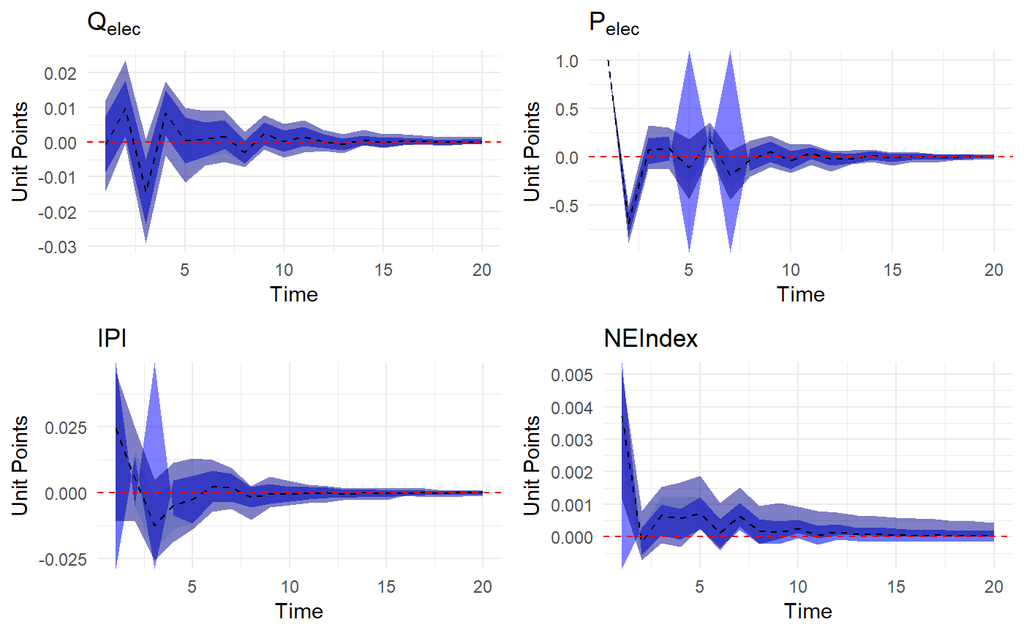

```r
library(latex2exp)

names <- c('$Q_{elec}$','$P_{elec}$', "IPI", '$NE Index$')

n <- length(names)
plot_irf_mini_panel_tot <- function(i){
  #i=1
  main_prediction <- lambda_0_control[, i, 2]
  time_horizon <- 1:20

  strong_band_inf <-
    strong_instruments_lambda_GK_control[,i,"lower","lambda_02"]
  strong_band_sup <-
    strong_instruments_lambda_GK_control[,i,"upper","lambda_02"]


  pointwise_inf_weak_band <-
    weak_instruments_pointwise_GK_control[,i,"lower","lambda_02"]
  pointwise_sup_weak_band <-
    weak_instruments_pointwise_GK_control[, i,"upper","lambda_02"]

  bonferroni_inf_weak_band <-
    weak_instruments_bondferroni_GK_control[, i,"lower","lambda_02"]
  bonferroni_sup_weak_band <-
    weak_instruments_bondferroni_GK_control[, i,"upper","lambda_02"]

  # Plot the responses for each variable

  my_plot <- ggplot()+

  geom_ribbon(aes(x=time_horizon, ymin = bonferroni_inf_weak_band,
        ymax = bonferroni_sup_weak_band), fill = "lightblue", alpha = 0.5) +

    geom_ribbon(aes(x=time_horizon, ymin = pointwise_inf_weak_band,
        ymax = pointwise_sup_weak_band), fill = "blue", alpha = 0.5) +

       geom_ribbon(aes(x=time_horizon, ymin = strong_band_inf,
        ymax = strong_band_sup), fill = "darkblue", alpha = 0.5) +

    # ggtitle(expression(paste(names[i]))) +
    labs(title = TeX(names[i]),
      x = "Time",
      y = "Unit Points") +
    geom_line(aes(x=time_horizon, y= main_prediction), linetype='dashed')+
    geom_hline(yintercept = 0, linetype = 'dashed', color = 'red') +
    scale_x_continuous()+
    scale_y_continuous()+
    # Add confidence bands
    theme_minimal()
  return(my_plot)
}


# Apply the function to the sequence 3:10
results <- lapply(c(1:n) , plot_irf_mini_panel_tot)

# Arrange the plots in a grid
plots_grid <- do.call("grid.arrange", c(results, nrow = 2))
```

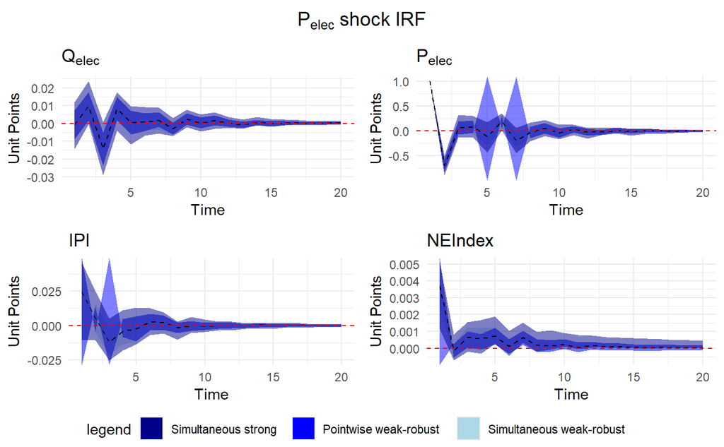

```r
final_plot <- plot_grid(plots_grid, custom_legend , ncol = 1, rel_heights = c(1, 0.1))

title <- ggdraw() +
  draw_label(TeX('$P_{elec}$ shock IRF'), fontface = 'bold', x = 0.5, hjust = 0.5)

# Combine the title and the final plot with legend
final_plot_with_title <- plot_grid(title, final_plot, ncol = 1, rel_heights = c(0.1, 1))

# Display the final plot
print(final_plot_with_title)
```